# Lab 06: Logistic Regression

PAF 512 - Advanced Regression

Lab Solutions

## AI & Coding Policy

- **Responsible AI Use:** Use AI to *support* your learning (debugging, explaining), not to *replace* it. Submitting code or answers generated by AI is not permitted.
- **Course Methods Required:** Please solve these problems using the specific R techniques taught in this module. AI may suggest shortcuts or different packages; avoid using these, as work relying on methodologies not found in the course materials will result in a loss of credit.

## Instructions

There are **4 sets of questions** to be answered, plus a bonus question. You can earn up to **100 points + 10 bonus points**. Points are indicated next to each question.

Remember to:

- Format your tables using `stargazer`
- Answer all parts of each question
- Submit the R markdown file & HTML with all your code
- **Bold your answers**

## The Policy Problem

This lab is loosely based on the research conducted by Doan & Kirkpatrick (2013) entitled “Giving Girls a Shot: An Examination of Mandatory Vaccination Legislation” and published in *Policy Studies Journal*, 41(2), 295-318.

> **Research Question:** What factors influence a states decision to introduce mandatory HPV vaccine legislation for young girls?

Doan and Kirkpatrick (2013) analyze state’s decision to introduce a mandatory vaccine for the human papillomavirus (HPV) for all fifth- and sixth-grade girls in public schools. The vaccine was approved in 2006 and patented by Merck & Co. The two researchers were particularly interested in the influence of competing morality, economic, and public-health determinants on states’ decision making.

With regards to morality, they suggest that state politicians are responsive to the public opinion within their own state, such that they will respond to positive or negative approval of the new legislation. For instance, a high proportion of Evangelics or Catholics within the state might discourage mandatory HPV vaccine legislation as those groups have conservative view regarding sexuality and sexual activity and might disapprove of the vaccine at such early age. Similarly, a high rate of negative media attention might decrease politicians’ motivation to introduce legislation mandating the HPV vaccine in order to remain aligned with the electorate’s preferences.

By contrast, we could expect politicians to support their party’s values. “Social welfare” is generally an issue associated with Democrats, which might have greater incentives to pass a mandatory HPV vaccine regulation to appeal to their electoral basis as compared to Republicans.

Finally, politicians might respond to political interests and support policies in favor of private organizations providing resources for their electoral campaign. We might expect that states where politicians receive more money from Merck & Co will be more likely to adopt such legislation.

> **Hypotheses:**
> - Media salience is negatively correlated with mandatory legislation.
> - Proportion of state legislature that is Democrat is positively correlated with mandatory legislation.
> - Religiosity (percentage of the population that is Catholic or Evangelical) is negatively correlated with mandatory legislation.
> - Merck PAC contributions are positively correlated with mandatory legislation.

Given that the dependent variable is a binary outcome (1/0), a probability model is appropriate. Answer the questions below using a linear probability model and a logistic regression model.

## Data

### Load Packages

```r
# Install packages if needed
# install.packages("stargazer")
# install.packages("sandwich")
# install.packages("lmtest")
# install.packages("margins")

library(stargazer)    # Clean regression tables
library(sandwich)     # Robust standard errors
library(lmtest)       # Coefficient testing with robust SEs
library(margins)      # Marginal effects for logit models
```

### Load Data

```r
URL <- "https://raw.githubusercontent.com/DS4PS/pe4ps-textbook/master/labs/DATA/logit-lab.csv"
data <- read.csv(URL, stringsAsFactors = FALSE)

head(data)
```

```
##   Adoption Democrats Evangelics Catholics Media Merck
## 1        0      0.36       0.00      0.14   502  2914
## 2        0      0.57       0.82      0.58   150  1636
## 3        1      0.53       0.62      0.26   144  4153
## 4        1      0.91       0.66      0.14    31  4311
## 5        1      0.00       0.56      0.41   277  4643
## 6        0      0.66       0.57      0.52   800  2378
```

### Pre-Scale Proportion Variables in Decimal Form

> **Note: Important Data Scaling Issue**

> In this dataset, **Democrats**, **Evangelics**, and **Catholics** are recorded as decimals between 0 and 1 (0.50), and represent the proportion of the population in each respective group.

> **The Problem:** A “1-unit increase” in these variables means going from 0 to 1, which represents going from 0% to 100% of the population. That’s unrealistic - we care about smaller changes like going from 30% to 31% so our results are more meaningful and interpretable.

> **The loaded data has been completed for you already, but the following two options are how you can fix it on your own in the future.**

> **How to Fix It:** - **Option One:** Convert each coefficient to be at the 1 percentage point increase level by dividing by 100. This requires many more steps throughout the modeling process and opens the door for additional errors. - **Option Two:** Scale your entire column to no longer be constrained between 0 and 1, instead, 0 and 100 by multiplying by 100 at the column variable level. Once done, our data contains pre-scaled variables for a 1-percentage point unit change.

> **Bottom Line:** Your data contains columns with scaled variables (`Democrats_s`, `Evangelics_s`, `Catholics_s`), be sure to use those.

```r
# Create new columns with our scaled variables
## We only scale the variables that are proportions and in decimal form
data$Democrats_s <- round(data$Democrats * 100, 5)
data$Evangelics_s <- round(data$Evangelics * 100, 5)
data$Catholics_s <- round(data$Catholics * 100, 5)

# Preview Results
head(data)
```

```
##   Adoption Democrats Evangelics Catholics Media Merck Democrats_s Evangelics_s
## 1        0      0.36       0.00      0.14   502  2914          36            0
## 2        0      0.57       0.82      0.58   150  1636          57           82
## 3        1      0.53       0.62      0.26   144  4153          53           62
## 4        1      0.91       0.66      0.14    31  4311          91           66
## 5        1      0.00       0.56      0.41   277  4643           0           56
## 6        0      0.66       0.57      0.52   800  2378          66           57
##   Catholics_s
## 1          14
## 2          58
## 3          26
## 4          14
## 5          41
## 6          52
```

```r
# Confirm scaled variables are contained between 0 and 100 now
summary(data)
```

```
##     Adoption        Democrats        Evangelics       Catholics
##  Min.   :0.0000   Min.   :0.0000   Min.   :0.0000   Min.   :0.0000
##  1st Qu.:0.0000   1st Qu.:0.3300   1st Qu.:0.4600   1st Qu.:0.2700
##  Median :0.0000   Median :0.4200   Median :0.6200   Median :0.3900
##  Mean   :0.3265   Mean   :0.4627   Mean   :0.5984   Mean   :0.3922
##  3rd Qu.:1.0000   3rd Qu.:0.5800   3rd Qu.:0.7500   3rd Qu.:0.5200
##  Max.   :1.0000   Max.   :1.0000   Max.   :1.0000   Max.   :1.0000
##      Media           Merck       Democrats_s      Evangelics_s
##  Min.   :  0.0   Min.   :   0   Min.   :  0.00   Min.   :  0.00
##  1st Qu.:236.0   1st Qu.:2501   1st Qu.: 33.00   1st Qu.: 46.00
##  Median :321.0   Median :3073   Median : 42.00   Median : 62.00
##  Mean   :331.4   Mean   :3134   Mean   : 46.27   Mean   : 59.84
##  3rd Qu.:464.0   3rd Qu.:3932   3rd Qu.: 58.00   3rd Qu.: 75.00
##  Max.   :800.0   Max.   :5000   Max.   :100.00   Max.   :100.00
##   Catholics_s
##  Min.   :  0.00
##  1st Qu.: 27.00
##  Median : 39.00
##  Mean   : 39.22
##  3rd Qu.: 52.00
##  Max.   :100.00
```

### Variable Descriptions

| Variable Name | Description |
| --- | --- |
| `Adoption` | Whether a state legislature has considered a mandatory vaccine law (=1) or not (=0) |

#### Null non-scaled variables to prevent confusion

```r
# Prevent the use of these columns accidentally
data$Democrats <- NULL
data$Evangelics <- NULL
data$Catholics <- NULL
```

## Lab Questions

### Question 1: The Linear Probability Model (30 points)

#### Q1a: Run a linear probability model (LPM) predicting Adoption using all five independent variables. Present the results using stargazer. (5 points)

> **Note:** A linear probability model is simply an OLS model (`lm()`) where the dependent variable is binary (0/1).

````r
# Reminder: While completing your lab, set #type = "text" for your stargazer(), but, remember to set type = "html" when you are ready to knit and submit your lab. You will also need to include in your code chunk header results =' asis' to properly render the table in the knitted HTML file. Your code chunk header should look like this: ```{r, results = 'asis'}

# Run the Linear Probability Model
LPM <- lm(Adoption ~ Democrats_s + Evangelics_s + Catholics_s + Media + Merck, data = data)

stargazer(LPM,
          type = "html",
          ##type = "text",
          title = "Linear Probability Model: HPV Vaccine Legislation Adoption",
          dep.var.labels = "Adoption",
          intercept.bottom = FALSE,
          omit.stat = c("ser", "f"),
          digits = 6)
````

**Linear Probability Model: HPV Vaccine Legislation Adoption**

|  | *Dependent variable:* |
| --- | --- |
|  | Adoption |
| Constant | 1.381158*** |
|  | (0.336155) |
| Democrats_s | -0.000487 |
|  | (0.002571) |
| Evangelics_s | -0.006982** |
|  | (0.003053) |
| Catholics_s | 0.002145 |
|  | (0.002893) |
| Media | -0.001718*** |
|  | (0.000349) |
| Merck | -0.000041 |
|  | (0.000055) |
| Observations | 49 |
| R<sup>2</sup> | 0.373206 |
| Adjusted R<sup>2</sup> | 0.300323 |
| *Note:* | p<0.1; p<0.05; p<0.01 |

#### Q1b: Calculate robust standard errors for the LPM. Display both the non-robust and robust models side-by-side using stargazer. (5 points)

> **Note:** The LPM suffers from heteroskedasticity by construction. Robust standard errors correct for this. Use `vcovHC()` from the `sandwich` package and supply the robust SEs to stargazer using the `se = list()` argument.

```r
# Calculate robust standard errors
cov_lpm <- vcovHC(LPM, type = "HC1")
robust_se <- sqrt(diag(cov_lpm))

# Present with robust SEs
stargazer(LPM,LPM,
          type = "html",
          #type = "text",
          se = list(NULL, robust_se),
          column.labels = c("Standard SEs", "Robust SEs"),
          title = "Linear Probability Model with Robust Standard Errors",
          dep.var.labels = "Adoption",
          covariate.labels = c("Constant", "Democrats",
                               "Evangelics",
                               "Catholics",
                               "Media (Articles)",
                               "Merck (Dollars)"),
          intercept.bottom = FALSE,
          omit.stat = c("ser", "f"),
          digits = 5)
```

**Linear Probability Model with Robust Standard Errors**

|  | *Dependent variable:* |  |
| --- | --- | --- |
|  | Adoption |  |
|  | Standard SEs | Robust SEs |
|  | (1) | (2) |
| Constant | 1.38116*** | 1.38116*** |
|  | (0.33616) | (0.33682) |
| Democrats | -0.00049 | -0.00049 |
|  | (0.00257) | (0.00247) |
| Evangelics | -0.00698** | -0.00698** |
|  | (0.00305) | (0.00282) |
| Catholics | 0.00214 | 0.00214 |
|  | (0.00289) | (0.00231) |
| Media (Articles) | -0.00172*** | -0.00172*** |
|  | (0.00035) | (0.00028) |
| Merck (Dollars) | -0.00004 | -0.00004 |
|  | (0.00006) | (0.00006) |
| Observations | 49 | 49 |
| R<sup>2</sup> | 0.37321 | 0.37321 |
| Adjusted R<sup>2</sup> | 0.30032 | 0.30032 |
| *Note:* | p<0.1; p<0.05; p<0.01 |  |

#### Q1c: Which variables are statistically significant predictors of adoption? For each significant variable, report the coefficient name, its raw value, the estimated change in probability in percentage points (e.g., 0.05 becomes 5 percentage points), significance level, and the direction of its effect on the probability of adoption. (10 points)

> **Note:** Remember that Democrats_s, Evangelics_s, and Catholics_s were pre-scaled.

```r
# Show your work, if desired, when converting to % change

# Subset Evangelics coefficient
evangelics_pc <- 100 * LPM$coefficients[3]

# Subset Media coefficient
media_pc <- 100 * LPM$coefficients[5]

cat("For every 1-percentage point increase in Evangelic population we estimate the likelihood of adoption changes by ", round(evangelics_pc, 3),"%", "\n\n",
    "Every additional article about HPV changes the likelihood of adoption by ", round(media_pc, 3), "%")
```

```
## For every 1-percentage point increase in Evangelic population we estimate the likelihood of adoption changes by  -0.698 %
##
##  Every additional article about HPV changes the likelihood of adoption by  -0.172 %
```

**Based on the robust standard errors, only two variables are statistically significant:**

- **Media:** The raw coefficient is $-0.0017$ and is statistically significant at the $p < 0.01$ level. This negative coefficient indicates that each additional media article covering the HPV vaccine issue decreases the probability of adoption by approximately 0.17 percentage points. This supports the hypothesis that increased media salience is negatively correlated with mandatory legislation.
- **Evangelics:** The raw coefficient is $-0.006981973$ and is statistically significant at the $p < 0.05$ level. This negative coefficient indicates that for every 1 percentage point increase in the Evangelical population mandatory HPV vaccine adoption decreases by approximately $0.7$ percentage points. This supports the hypothesis that religiosity is negatively correlated with mandatory legislation.

#### Q1d: Robust standard errors solve the heteroskedasticity problem in LPMs. What are the other two limitations of the linear probability model? (10 points)

**1. Predicted values are not constrained between 0 and 1.** Since the LPM uses a linear function, it is possible to get predicted probabilities that are less than $0$ or greater than $1$. A probability below $0$ or above $1$ is not meaningful and violates the fundamental definition of probability.

**2. The LPM assumes a linear relationship between the independent variables and the probability of the outcome.** However, the true relationship between predictors and probability is generally non-linear - it follows an S-shaped curve. The LPM may provide a reasonable approximation in the middle range of the data, but it does a poor job at the extremes (very high or very low values of the independent variables). At the extremes, the marginal effect of a one-unit change should diminish, but the LPM assumes a constant marginal effect across all values.

### Question 2: The Logit Model (20 points)

#### Q2a: What estimator does the logit model use instead of OLS, and what shape does the predicted probability curve take? Briefly explain why this shape is preferred over the linear probability model. (5 points)

**The logit model uses Maximum Likelihood Estimation (MLE) instead of OLS. MLE is an estimation method that finds the set of coefficients most likely to have generated the observed data, given the assumption that the data follows a logistic distribution.**

**The predicted probability curve takes an S-shaped curve. This S-shape is preferred over the linear function because it:**

**1. Constrains predicted probabilities between $0$ and $1$**, which respects the natural boundaries of probability.

**2. Better approximates how probabilities actually behave** — the effect of an independent variable on probability is largest in the middle range and diminishes at the extremes, reflecting diminishing marginal effects. This matches real-world behavior where moving from 10% to 11% probability is easier than moving from 99% to 100%.

#### Q2b: Run the logit model using `glm()` with `family = "binomial"` and present BOTH the LPM and logit models side-by-side using stargazer. (10 points)

> **Note:** Remember that Democrats_s, Evangelics_s, and Catholics_s were pre-scaled.

```r
# Run the logit model
logit_model <- glm(Adoption ~ Democrats_s + Evangelics_s + Catholics_s + Media + Merck,
                   data = data,
                   family = "binomial")


# Present LPM and logit side-by-side
stargazer(LPM, logit_model,
          type = "html",
          #type = "text",
          title = "Comparison: Linear Probability Model vs. Logit Model",
          column.labels = c("LPM", "Logit"),
          dep.var.labels = "Adoption",
          covariate.labels = c("Constant", "Democrats",
                               "Evangelics",
                               "Catholics",
                               "Media (Articles)",
                               "Merck (Dollars)"),
          intercept.bottom = FALSE,
          omit.stat = c("ser", "f"),
          digits = 5)
```

**Comparison: Linear Probability Model vs. Logit Model**

|  | *Dependent variable:* |  |
| --- | --- | --- |
|  | Adoption |  |
|  | *OLS* | *logistic* |
|  | LPM | Logit |
|  | (1) | (2) |
| Constant | 1.38116*** | 7.71765*** |
|  | (0.33616) | (2.96232) |
| Democrats | -0.00049 | -0.00716 |
|  | (0.00257) | (0.01907) |
| Evangelics | -0.00698** | -0.06044** |
|  | (0.00305) | (0.02682) |
| Catholics | 0.00214 | 0.01593 |
|  | (0.00289) | (0.02671) |
| Media (Articles) | -0.00172*** | -0.01515*** |
|  | (0.00035) | (0.00474) |
| Merck (Dollars) | -0.00004 | -0.00023 |
|  | (0.00006) | (0.00034) |
| Observations | 49 | 49 |
| R<sup>2</sup> | 0.37321 |  |
| Adjusted R<sup>2</sup> | 0.30032 |  |
| Log Likelihood |  | -18.80199 |
| Akaike Inf. Crit. |  | 49.60399 |
| *Note:* | p<0.1; p<0.05; p<0.01 |  |

#### Q2c: Can you directly compare the coefficient values between the LPM and logit models? Why or why not? (5 points)

**No, you cannot directly compare the coefficient values between the LPM and logit models because the coefficients are measured on different scales.**

**In the LPM, coefficients represent the change in the probability of adoption for a one-unit increase in the independent variable. These are directly interpretable as changes in probability (though remember the scaling issue for proportion variables).**

**In the logit model, the raw coefficients represent changes in the log-odds of adoption for a one-unit increase in the independent variable. Log-odds are not directly interpretable as changes in probability. To make logit coefficients meaningful, we need to transform them into odds ratios (by exponentiating), predicted probabilities, or marginal effects.**

### Question 3: Interpreting Logit Coefficients (30 points)

#### Q3a: Transform the logit model coefficients into odds ratios using `exp()`. Report and interpret the odds ratio for the Evangelics variable. (5 points)

> **Note:** Remember that Democrats_s, Evangelics_s, and Catholics_s were pre-scaled.

```r
# actual answer
exp(cbind(OR = coef(logit_model), confint(logit_model)))
```

```
##                        OR      2.5 %       97.5 %
## (Intercept)  2247.6696731 12.3964589 1.877961e+06
## Democrats_s     0.9928651  0.9550478 1.031990e+00
## Evangelics_s    0.9413515  0.8856301 9.869214e-01
## Catholics_s     1.0160532  0.9643811 1.073564e+00
## Media           0.9849662  0.9737659 9.925529e-01
## Merck           0.9997686  0.9990626 1.000430e+00
```

**The odds ratio for pre-scaled Evangelics is approximately 0.94.**

**Interpretation: For each 1 percentage point increase in the Evangelical population (e.g., going from 12% to 13%), the odds of a state adopting mandatory HPV vaccine legislation are multiplied by approximately 0.94. Since this value is less than 1, it indicates that higher percentages of Evangelicals are associated with lower odds of adoption.**

#### Q3b: Use the probability formula to calculate the predicted probability of adopting mandatory vaccine legislation for an average state (i.e., a state where all variables are set at their means). Show your work. (10 points)

> **Note:** Plug in the raw mean of each independent variable and the coefficients from your logit model. Stick with the methods shown in the codethrough.

$$P = \frac{1}{1 + e^{-(\beta_0 + \beta_1 X_1 + \beta_2 X_2 + \beta_3 X_3
+ \cdots)}} \tag{3.1}$$

```r
# Get the means of each variable
mean_demo <- mean(data$Democrats_s)
mean_evan <- mean(data$Evangelics_s)
mean_cath <- mean(data$Catholics_s)
mean_media <- mean(data$Media)
mean_merck <- mean(data$Merck)

cat("Variable means:\n",
    "Democrats:", round(mean_demo, 4), "\n",
    "Evangelics:", round(mean_evan, 4), "\n",
    "Catholics:", round(mean_cath, 4), "\n",
    "Media:", round(mean_media, 2), "\n",
    "Merck:", round(mean_merck, 2), "\n\n")
```

```
## Variable means:
##  Democrats: 46.2653
##  Evangelics: 59.8367
##  Catholics: 39.2245
##  Media: 331.45
##  Merck: 3134.22
```

```r
# Extract coefficients
b <- coef(logit_model)

# Manually calculate
log_odds <- b[1] + b[2]*mean_demo + b[3]*mean_evan + b[4]*mean_cath + b[5]*mean_media + b[6]*mean_merck

# Convert to probability using the formula
prob_avg <- 1 / (1 + exp(-log_odds))

cat("Log-odds for average state:", round(log_odds, 4), "\n")
```

```
## Log-odds for average state: -1.3514
```

```r
cat("Predicted probability:", round(prob_avg, 6), "\n")
```

```
## Predicted probability: 0.205635
```

```r
cat("Percentage:", round(prob_avg * 100, 2), "%\n")
```

```
## Percentage: 20.56 %
```

**The predicted probability of adoption for an average state is approximately 0.2056, or 20.56%. This means that a state with average values on all five variables has approximately a 20.56% chance of adopting mandatory HPV vaccine legislation.**

#### Q3c: Compared to the average state, how much does the probability change for a state that has a particularly high media coverage, equal to the 95th percentile? Use the `predict()` function. Calculate the predicted probability for the average state, the percentile state, and the difference (discrete change) between the two. (5 points)

> **Note:** make sure you column names match the ’_s’ convention. Predict looks for the same named variables in your logit model, if they’re different you will get an error.

```r
# Create data for an average state
avg_state <- data.frame(
  Democrats_s = mean(data$Democrats_s),
  Evangelics_s = mean(data$Evangelics_s),
  Catholics_s = mean(data$Catholics_s),
  Media = mean(data$Media),
  Merck = mean(data$Merck)
)

# Predict probability for the average state
prob_avg_predict <- predict(logit_model, newdata = avg_state, type = "response")

# Create data for a state with 95th percentile media coverage
high_media_state <- avg_state
high_media_state$Media <- quantile(data$Media, 0.95)

# Predict probability for high-media state
prob_high_media <- predict(logit_model, newdata = high_media_state, type = "response")

# Discrete change
discrete_change_media <- prob_high_media - prob_avg_predict

cat("95th percentile Media coverage:", quantile(data$Media, 0.95), "articles\n",
    "Probability for average state:", round(prob_avg_predict, 6), "\n",
    "Probability for high-media state:", round(prob_high_media, 6), "\n",
    "Discrete change:", round(discrete_change_media, 6), "\n")
```

```
## 95th percentile Media coverage: 622 articles
##  Probability for average state: 0.205635
##  Probability for high-media state: 0.003164
##  Discrete change: -0.202471
```

**The predicted probability for a state with media coverage at the 95th percentile (622 articles) is approximately 0.003, compared to approximately 0.2056 for the average state. The discrete change is approximately -0.202471, meaning that moving from average media coverage to the 95th percentile decreases the probability of adoption by approximately 20.2 percentage points. This demonstrates the strong negative effect of high media coverage on the likelihood of adoption.**

#### Q3d: Compared to the average state, how much does the probability change for a state with a particularly low percentage of Evangelicals, equal to the 25th percentile? Use the `predict()` function. Calculate the predicted probability for the average state, the percentile state, and the difference (discrete change) between the two. (5 points)

> **Note:** Remember to name your new data frame columns the same as your logit model variable names or you will get an error.

```r
# Create data for a state with 25th percentile Evangelics
low_evan_state <- avg_state
low_evan_state$Evangelics_s <- quantile(data$Evangelics_s, 0.25)

# Predict probability for low-Evangelic state
prob_low_evan <- predict(logit_model, newdata = low_evan_state, type = "response")

# Discrete change
discrete_change_evan <- prob_low_evan - prob_avg_predict

cat("25th percentile Evangelic population:", round(quantile(data$Evangelics_s, 0.25), 2), "\n",
    "Probability for average state:", round(prob_avg_predict, 6), "\n",
    "Probability for low-Evangelic state:", round(prob_low_evan, 6), "\n",
    "Discrete change:", round(discrete_change_evan, 6), "\n")
```

```
## 25th percentile Evangelic population: 46
##  Probability for average state: 0.205635
##  Probability for low-Evangelic state: 0.373983
##  Discrete change: 0.168348
```

**The predicted probability for a state with Evangelical population at the 25th percentile (46%) is approximately 0.374, compared to approximately 0.2056 for the average state. The discrete change is approximately 0.1683, meaning that having a lower Evangelical population (25th percentile vs. mean) increases the probability of adoption by approximately 16.83 percentage points. This confirms that states with lower Evangelical populations are more likely to consider mandatory HPV vaccine legislation.**

#### Q3e: Create a plot showing how the predicted probability of adoption changes as the percentage of Evangelicals ranges from 0 to 100. Hold all other variables at their means. (5 points)

> **Note:** Be cognisant of the fact that our Evangelic variable is pre-scaled, so it ranges from 0 to 100, not 0 to 1. Make sure your x-axis reflects this.

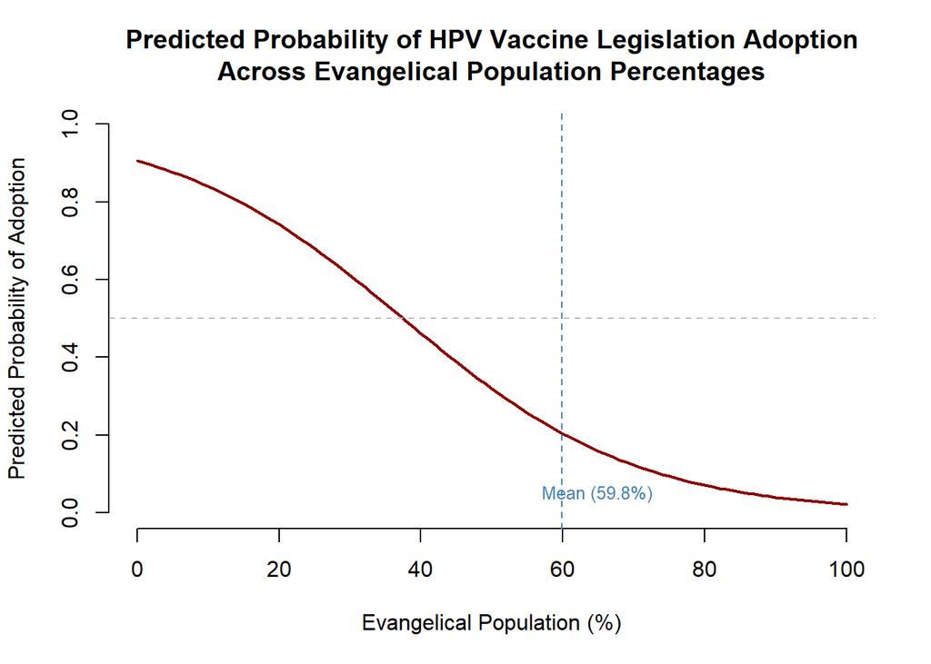

```r
# Create a data frame with Evangelic varying from 0 to 100 (as proportions 0 to 1)
plot_data <- data.frame(
  Democrats_s = mean(data$Democrats_s),
  Evangelics_s = seq(0, 100, by = 1),  # 0 to 100 in increments of 1
  Catholics_s = mean(data$Catholics_s),
  Media = mean(data$Media),
  Merck = mean(data$Merck)
)

# Predict probabilities
plot_data$predicted_prob <- predict(logit_model, newdata = plot_data, type = "response")

# Plot
plot(plot_data$Evangelics_s, plot_data$predicted_prob,
     type = "l", lwd = 2, col = "darkred",
     xlab = "Evangelical Population (%)",
     ylab = "Predicted Probability of Adoption",
     main = "Predicted Probability of HPV Vaccine Legislation Adoption\nAcross Evangelical Population Percentages",
     bty = "n",
     ylim = c(0, 1))

# Add reference lines
abline(h = 0.5, lty = 2, col = "gray")
abline(v = mean(data$Evangelics_s) , lty = 2, col = "steelblue")
text(mean(data$Evangelics_s) + 5, 0.05,
     paste0("Mean (", round(mean(data$Evangelics_s) , 1), "%)"),
     col = "steelblue", cex = 0.8)
```

### Question 4: Marginal Effects (20 points)

#### Q4a: Calculate the average marginal effects (AME) for all variables in the logit model using the `margins()` function. Which variable has the highest average marginal effect between Media and Evangelic? Report both AME values. (5 points)

> Note: We’re looking for the largest **absolute** value

```r
# Calculate average marginal effects
m <- margins(logit_model)
summary(m)
```

```
##        factor     AME     SE       z      p   lower   upper
##   Catholics_s  0.0020 0.0033  0.6046 0.5454 -0.0044  0.0084
##   Democrats_s -0.0009 0.0024 -0.3776 0.7057 -0.0055  0.0037
##  Evangelics_s -0.0075 0.0026 -2.8920 0.0038 -0.0126 -0.0024
##         Media -0.0019 0.0003 -6.8502 0.0000 -0.0024 -0.0013
##         Merck -0.0000 0.0000 -0.6986 0.4848 -0.0001  0.0001
```

**The average marginal effect of Media is approximately -0.0019 and the average marginal effect of Evangelics is approximately -0.0075. The variable with the highest average marginal effect in absolute value between the two is Evangelics_s, with an AME of -0.0075 compared to Media’s -0.0019.**

**This means that, on average across all observations, a one percentage point change in Evangelic population decreases the probability of adoption by approximately .75 percentage points.**

#### Q4b: Does an increase in the Evangelical population have a greater effect in a state where the current percentage is 20% or 40%? Calculate the marginal effect of Evangelic at both values and explain why they differ. (10 points)

> **Note:** Remember to use our pre-scaled variable. Use rbind() to vertically stack both objects for a nicer display.

```r
# Marginal effect of Evangelic at 20% (0.20 as proportion)
me_20 <- margins(logit_model, at = list(Evangelics_s = 20), variables = "Evangelics_s")

# Marginal effect of Evangelic at 40% (0.40 as proportion)
me_40 <- margins(logit_model, at = list(Evangelics_s = 40), variables = "Evangelics_s")

rbind(summary(me_20), summary(me_40))
```

```
##        factor Evangelics_s     AME     SE       z      p   lower   upper
##  Evangelics_s      20.0000 -0.0073 0.0020 -3.6800 0.0002 -0.0112 -0.0034
##  Evangelics_s      40.0000 -0.0080 0.0029 -2.8085 0.0050 -0.0136 -0.0024
```

**The marginal effect of Evangelic at 20% is approximately -0.0073 and at 40% is approximately -0.0080. The marginal effect is larger in absolute value at 40% than at 20%.**

**The marginal effects differ because of the non-linear (S-shaped) nature of the logit model. Unlike a linear model where the marginal effect is constant, the logit model’s marginal effect depends on where you are on the probability curve.**

**At 40% Evangelical population, the state is likely on a steeper part of the S-curve where changes in the independent variable have a larger impact on the probability. At 20% Evangelical population, the state may be on a flatter portion of the curve where the same change has a smaller impact. This is a fundamental property of logistic regression - the same one-unit change in a predictor has different effects on probability depending on the starting point and where that puts you on the probability curve.**

#### Q4c: Imagine you work for an advocacy group trying to **promote the adoption** of mandatory HPV vaccine legislation across states. Part of your effort is to decrease negative media coverage. Would you rather invest in a state where the media coverage is equal to 200 or in a state where the media coverage is equal to 400? Calculate the marginal effect at both values and explain your recommendation. (5 points)

```r
# Marginal effect of Media at 200
me_media_200 <- margins(logit_model, at = list(Media = 200), variables = "Media")

# Marginal effect of Media at 400
me_media_400 <- margins(logit_model, at = list(Media = 400), variables = "Media")

rbind(summary(me_media_200), summary(me_media_400))
```

```
##  factor    Media     AME     SE       z      p   lower   upper
##   Media 200.0000 -0.0028 0.0006 -4.3961 0.0000 -0.0040 -0.0015
##   Media 400.0000 -0.0014 0.0003 -4.4053 0.0000 -0.0021 -0.0008
```

**The marginal effect of Media at 200 articles is approximately -0.0028 and at 400 articles is approximately -0.0014. The marginal effect is larger in absolute value at Media = 200.**

**Recommendation: I would invest in the state where the media coverage is 200 articles, because reducing media coverage there would produce a larger change in the probability of adoption. The marginal effect at 200 articles (-0.0028) is approximately double the magnitude than at 400 articles (-0.0014). This means that the same dollar invested in reducing one media article would shift the probability of adoption more substantially in the state with 200 articles of coverage.**

**This is again due to the S-shaped nature of the logit model. At 200 articles, the state is likely in a position where adoption is still reasonably possible, so reducing negative coverage has a meaningful impact. At 400 articles, the state is probably already in a range where adoption is extremely unlikely, so even reducing coverage has a diminished effect - the state is on the flatter, lower tail of the probability curve.**

**From a resource allocation perspective, you get more “bang for your buck” by targeting states with moderate media coverage (200 articles) rather than states with very high media coverage (400 articles).**

### BONUS: LPM vs. Logit Out-of-Bound Predictions (10 points)

#### BQ1a: Using your LPM model from Q1, calculate the predicted probability of adoption for a state with the following profile: Democrats = 90, Evangelic = 5, Catholics = 5, Media = 50, Merck = 5000. Now calculate the predicted probability using your logit model from Q2 for the same state. What do you notice about the LPM prediction? Why is this problematic, and how does the logit model solve it? (10 points)

```r
# Create the extreme state profile
extreme_state <- data.frame(
  Democrats_s = 90,
  Evangelics_s = 5,
  Catholics_s = 5,
  Media = 50,
  Merck = 5000
)

# LPM prediction
lpm_prediction <- predict(LPM, newdata = extreme_state)
cat("LPM prediction:", round(lpm_prediction, 6), "\n")
```

```
## LPM prediction: 1.021667
```

```r
# Logit prediction
logit_prediction <- predict(logit_model, newdata = extreme_state, type = "response")
cat("Logit prediction:", round(logit_prediction, 6), "\n")
```

```
## Logit prediction: 0.99287
```

**The Linear Probability Model predicts a probability of 1.022 (or 102.2%) for this specific state.**

**The Logit model predicts a probability of 0.993 (or 99.3%) for the same state. The Logit model solves the unboundedness problem by using the logistic function (S-curve), which mathematically constrains all predicted probabilities to strictly fall between 0 and 1. As the independent variables increase, the curve asymptotically approaches 1 but never exceeds it.**

## Submission Instructions

When you have completed your assignment, knit your RMD file to generate your rendered HTML file.

1. Login to Canvas at http://canvas.asu.edu and navigate to the assignments tab in the course repository.
2. Upload your HTML and RMD files to the appropriate lab submission link.

**Remember to:**

- Include your name as the author in the YAML header.
- Name your files according to the convention: `Lab-06-LastName.Rmd`.
- Show your solution and include your code.
- Format your regression tables using `stargazer`.
- **Bold your answers.**
- Do **NOT** print excessive output (like a full data set).
- Follow appropriate style guidelines (spaces between arguments, etc.).

*Note: Platforms like BlackBoard and Canvas sometimes disallow you from submitting HTML files when there is embedded computer code. If this happens, create a zipped folder with both the RMD and HTML files.*

[output not shown]